# Florida Bay food web

Patrik Cavina

2025-12-17

# Analisi della food web Florida Bay nella stagione delle piogge

## Introduzione

Viene definita **food web** l’insieme delle catene alimentari all’interno di un ecosistema, che si intrecciano tra di loro formando una rete alimentare. I collegamenti all’interno di una food web indicano i trasferimenti di energia tra specie, indicando quale specie viene mangiata da un’altra.

La seguente analisi studia la food web della Florida bay nel periodo delle piogge. L’analisi inizia con il caricamento del dataset in formato paj e il preprocessamento dei dati calcolando il livello trofico per ogni specie. Successivamente vengono poste otto domande di ricerca, alla quale sarà data risposta in ogni capitolo dell’analisi. Le prime tre domande riguarderanno gli aspetti energetici della rete come biomassa e efficienza. Successivemente verranno analizate le specie dal punto di vista della loro alimentazione. Infine, verrà analizzata la rete in maniera comunitaria e globale per comprendere se la food web possa essere resiliente a cambiamenti.

```r
library(jsonlite)
library(readr)
library(igraph)
library(tidygraph)
library(tidyverse)
library(dplyr)
library(ggraph)
library(reshape2)
library(graphlayouts)

library(lpSolve)
library(lpSolveAPI)

library(patchwork)

# Restituisce un vettore con all'interno un colore per ogni livello trofico.
# L'indice del vottere indica il livello trofico
get_tl_colors = function() {
  colors = c("#1B9E77", "#D95F02", "#7570B3", "#E7298A", "#E6AB02")
  return(colors)
}
```

## Dataset

> Origine del dataset: [food web](http://konect.cc/networks/foodweb-baywet/) il cui corrispondente file .paj viene ricavato da .paj

Il dataset è una food web contenente le interazioni tra le specie presenti nella Florida Bay, un’ampia laguna all’estremo sud della florida, durante la stagione delle pioggie. Ogni nodo della rete rappresenta una taxa (specie, genere o famiglia), mentre ogni arco direzionato indica che una taxa ne usa un’altra come cibo (es. un arco tra $i$ e $j$, indica che $j$ usa $i$ come cibo).

```r
load_florida_graph = function(path) {
  stopifnot(file.exists(path))

  x = readLines(path, warn = FALSE)

  # --- 1) Estrai e leggi Network ---
  i0 = grep("^\\*Network\\b", x, ignore.case = TRUE)[1]
  if (is.na(i0)) stop("Nessuna sezione *Network trovata.")

  next_sec = grep("^\\*(Partition|Vector|Cluster)\\b", x[-seq_len(i0)], ignore.case = TRUE)[1]
  i1 = if (is.na(next_sec)) length(x) else i0 + next_sec - 1

  tmp = tempfile(fileext = ".net")
  on.exit(unlink(tmp))
  writeLines(x[i0:i1], tmp, useBytes = TRUE)
  g = read_graph(tmp, format = "pajek")

  # --- 2) Helper per leggere Partition/Vector ---
  read_vals = function(pattern) {
    h = grep(pattern, x, ignore.case = TRUE)[1]
    v_line = h + grep("^\\*Vertices\\b", x[-(1:h)], ignore.case = TRUE)[1]
    n = as.integer(sub("^\\*Vertices\\s+", "", x[v_line], ignore.case = TRUE))
    as.numeric(x[(v_line + 1):(v_line + n)])
  }

  # --- 3) Assegna attributi ---
  V(g)$eco_type = as.integer(read_vals("^\\*Partition\\s+ECO types\\b"))
  V(g)$bio_mass = read_vals("^\\*Vector\\s+bio-masses\\b")

  # --- 4) Rinomina primo attributo archi in "carbon_flow" ---
  if (length(edge_attr_names(g)) > 0) {
    E(g)$carbon_flow = edge_attr(g)[[1]]
    g = delete_edge_attr(g, edge_attr_names(g)[1])
  }

  return(g)
}

# Caricamento della food web
fw_g_io = load_florida_graph("data/florida.paj")
```

Il dataset è formato dal seguente numero di nodi e archi:

```r
cat("# Nodi: ", vcount(fw_g_io), "\n")
```

```
## # Nodi:  128
```

```r
cat("# Archi: ", ecount(fw_g_io))
```

```
## # Archi:  2106
```

Ogni nodo è composto dai seguenti attributi:

- name: nome della taxa
- eco_type: ruolo nella food web
  - 1 = taxa
  - 2 = detriti (“Particulate Organic Carbon” e “Dissolved Organic Carbon”)
  - 3 = input (energia proveniente dall’esterno della food web, es. radiazioni solari)
  - 4 = output (energia dispersa all’esterno della food web, es. calore)
  - 5 = respiration
- bio_mass: quantità di biomassa, misurata in $\frac{\text{g C}}{m^2}$

All’interno della rete i nodi indicati come detriti sono: * Water POC: materiale organico di dimensione millimetrica, presente nell’acqua * Benthic POC: materiale organico di dimensione millimetrica, presente sui fondali * DOC: materia organica di dimensioni microscopiche, funge da nutrimento per batteri e altri microrganismi

Ogni arco è etichettato dai seguenti attributi:

- carbon_flow: quantità di carbonio scambiata tra le due taxa, misurata in $\frac{\text{g C}}{m^2 \cdot year}$

Oltre al grafo `fw_g_io` vengono preparati anche:

- fw_g: grafo senza i vertici “Input”, “Output” e “Respiration”
- A: matrice di adiacenza associata a “fw_g”, dove avremo:
  - righe: produttori
  - colonne: consumatori
- A_norm: matrice di adicenza normalizzata per colonne, in questo modo otteniamo per ogni consumatore la percentuale che coprono i produttori nella sua dieta.

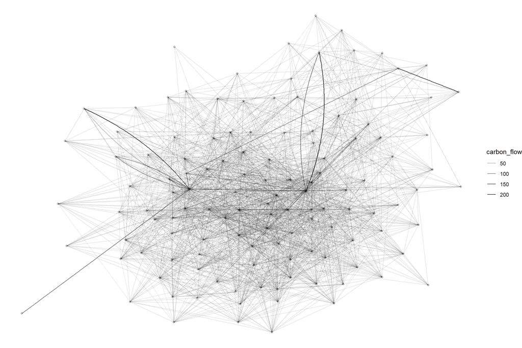

```r
# Rimuoviamo i vertici Input, Output, Respiration
fw_g = delete_vertices(fw_g_io, c('Input', 'Output', 'Respiration'))

# Righe: preda
# Colonne: predatore
A = as_adjacency_matrix(fw_g, names = TRUE, attr = "carbon_flow", sparse = FALSE)

# Normalizziamo per colonne per trovare le percentuali di ogni specie nella dieta di un predatore
A_norm = apply(A, 2, function(x)(x / sum(x)))
A_norm[is.nan(A_norm)] = 0

ggraph(fw_g, layout = "lgl") +
  geom_node_point(alpha = 0.2) +
  geom_edge_fan(aes(alpha = carbon_flow)) +
  theme_void()
```

> I termini taxa e specie verrano usati in maniera intercambiabile.

## Trophic level

Dato che non è sempre possibile assegnare una posizione intera all’interno della food web, possiamo usare la **fractional trophic level (TL)** per assegnare il livello trofico a ogni specie.

Il TL viene definito come:

$$TL_i = 1 + \sum_{j}(TL_j \cdot DC_{ij})$$

con:

- $TL_{i}$ livello trofico della specie $i$
- $TL_{j}$ livello trofico della specie $j$ predata da $i$
- $DC_{ij}$ frazione della specie $i$ nella dieta della specie $j$

In forma matriciale:

$$TL = 1 + DC \cdot TL$$

Possiamo ridurci a un sistema del tipo $Ax = b$ per calcolare il livello trofico di ogni specie, infatti:

$$TL - DC \cdot TL = 1 \\
(I - DC) \cdot TL = 1$$

Dove $TL$ è il vettore delle incognite $x$ e $(I - DC)$ la matrice nota $A$.

```r
# TL calcola il livello trofico per ogni specie nella matrice DC.
#
# INPUT
# DC: matrice delle frazioni di dieta, sulle righe sono presenti i predatori e sulle colonne le prede.
#
# OUTPUT
# tl: vettore dei livelli trofici per ogni specie
TL = function (DC) {
  n  = nrow(DC)
  I  = diag(n)
  b  = rep(1, n)

  tl = solve(I - DC, b)
  names(tl) = rownames(DC)
  return(tl)
}
```

Calcoliamo il livello trofico di ogni specie. Assumiamo che i detriti siano di livello trofico 1, in questo modo il livello trofico delle specie che se ne nutrono non sarà alterato.

```r
# Rimuoviamo gli archi entranti per i detriti POC e DOC, in questo modo questi
# vertici risulteranno come risorse basali (livello trofico 1)
A_norm2 = A_norm
A_norm2[, "Water POC"] = 0
A_norm2[, "Benthic POC"] = 0
A_norm2[, "DOC"] = 0

# Livello trofico per ogni specie
tls = TL(t(A_norm2))

# Livello trofico intero per ogni specie
tls_int = as.integer(tls)
names(tls_int) = names(tls)

# Assegniamo il livello trofico come attributo dei vertici
V(fw_g)$trophic_lvl = tls[V(fw_g)$name]

# Assegniamo il livello trofico intero come attributo dei vertici
V(fw_g)$trophic_lvl_int = tls_int[V(fw_g)$name]

# Assegniamo il livello trofico anche per la versione del grafo con input e output
fw_g_io = fw_g_io %>%
  as_tbl_graph() %>%
  activate(nodes) %>%
  left_join(
    igraph::as_data_frame(fw_g, what = "vertices")
      %>% select(name, trophic_lvl, trophic_lvl_int),
    by = 'name'
  ) %>%
  mutate(
    trophic_lvl = case_when(
      name == "Input" ~ 0, # Consideriamo l'input come livello trofico 0
      name == "Output" ~ 5, # Consideriamo l'output come livello trofico 5
      TRUE ~ trophic_lvl
    ),
    trophic_lvl_int = case_when(
      name == "Input" ~ 0.0,
      name == "Output" ~ 5.0,
      TRUE ~ trophic_lvl_int
    )
  ) %>%
  as.igraph()

# Riassunto dei livelli trofici
summary(tls)
```

```
##    Min. 1st Qu.  Median    Mean 3rd Qu.    Max.
##   1.000   2.201   3.278   2.931   3.619   4.602
```

Visualizziamo la distribuzione dei livelli trofici all’interno della rete.

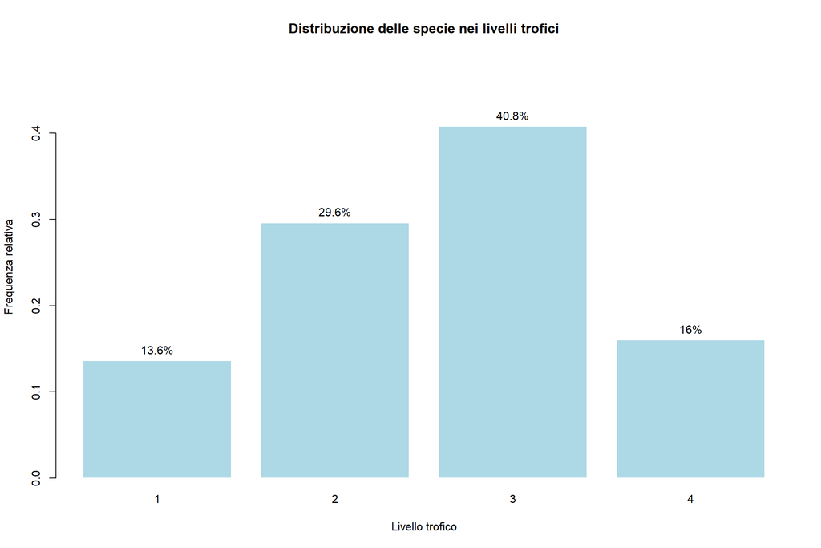

```r
# Calcolo la frazioni di specie per ogni ogni livello trofico
frac = table(tls_int) / length(tls_int)

# Distribuzione dei livelli trofici
bp = barplot(frac,
              col = "lightblue",
              main = "Distribuzione delle specie nei livelli trofici",
              xlab = "Livello trofico",
              ylab = "Frequenza relativa",
              border = "white",
              ylim = c(0, max(frac) * 1.2)
)
text(bp, frac, labels = paste0(round(frac * 100, 1), "%"), pos = 3)
```

Risulta che la maggior parte delle specie in questa food web sono di livello trofico 2 o 3, con una maggioranza significativa nel livello 3. Questo significa che la maggior parte delle specie sono onnivore o carnivore.

Grazie al livello trofico possiamo visualizzare la food web in maniera più ordinata.

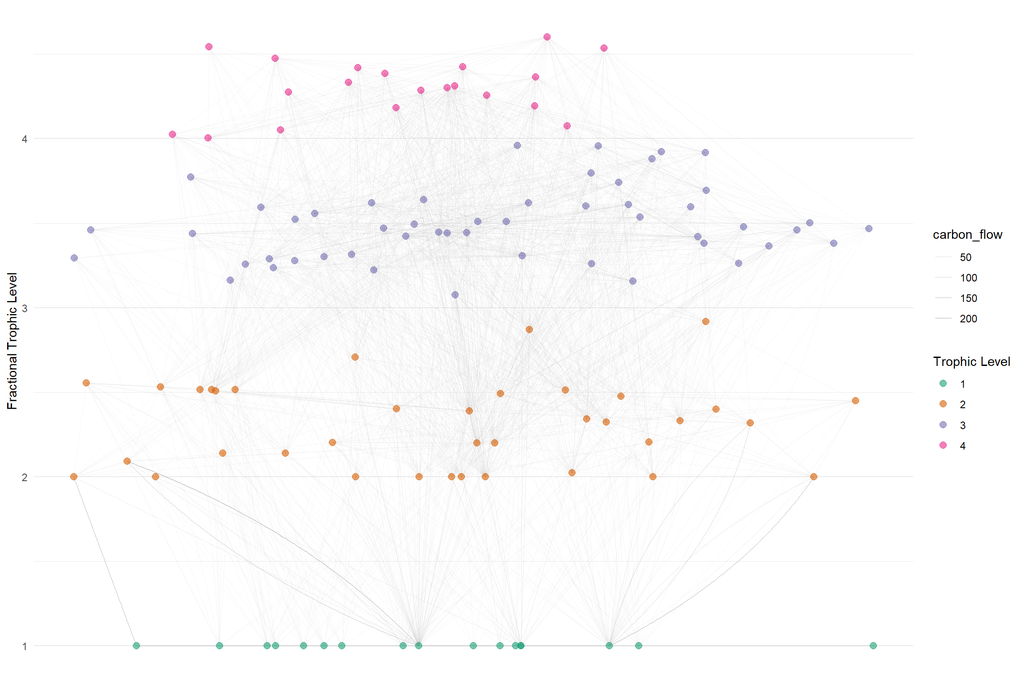

```r
coords = layout_igraph_constrained_stress(
  fw_g,
  coord = V(fw_g)$trophic_lvl,
  fixdim = "y"
)

ggraph(fw_g, layout = "manual", x = coords$x, y = coords$y) +
  geom_edge_fan(aes(alpha = carbon_flow), edge_colour = "darkgrey", linewidth = 0.25) +
  geom_node_point(aes(color = factor(trophic_lvl_int)), size = 2.5, alpha = 0.6) +
  scale_color_manual(values = get_tl_colors(), name = "Trophic Level") +
  scale_y_continuous(name = "Fractional Trophic Level") +
  theme_minimal() +
  theme(
    axis.title.x = element_blank(),
    axis.text.x  = element_blank(),
    axis.ticks.x = element_blank(),
    panel.grid.major.x = element_blank(),
    panel.grid.minor.x = element_blank()
  )
```

## Domande di ricerca

1. Come si distribuisce la biomassa tra i livelli trofici? Risposta 1
2. Qual’è l’efficienza di trasferimento energetico (Ecological Efficency) tra i livelli trofici? (10% law) Risposta 2
3. Quali sono le specie con più potere all’interno della food web? Risposta 3
4. Quali sono le specie centrali? Risposta 4
5. Quali sono i super predatori e le super prede? Cosa emerge analizzando i gradi della rete? Risposta 5
6. Studiando la connettività della rete, questa risulta resiliente? Risposta 6
7. Analizzando le comunità della rete, quali sotto food web emergono? C’è varietà trofica all’interno delle comunità? Risposta 7
8. Qual’è la lunghezza massima dei cammini minimi? Si presenta lo small-world effect all’interno della rete? Risposta 8

## Distribuzione della biomassa

Iniziamo analizzando come si distribuisce la biomassa nei livelli trofici. Consideriamo i detriti come livello trofico 0, in modo da poterne vedere le proporzioni con gli altri livelli.

```r
biomass_tl = fw_g %>%
  as_tbl_graph() %>%
  activate(nodes) %>%
  mutate(
    trophic_lvl = ifelse(eco_type == 2, 0.0, trophic_lvl),       # Indichiamo con 0 i detriti
    trophic_lvl_int = ifelse(eco_type == 2, 0, trophic_lvl_int), # Indichiamo con 0 i detriti
  ) %>%
  as_tibble() %>%
  group_by(trophic_lvl_int) %>%
  summarise(tot_biomass = sum(bio_mass), .groups = "drop") %>%
  mutate(perc = tot_biomass / sum(tot_biomass) * 100)
biomass_tl
```

| trophic_lvl_int | tot_biomass | perc |
| --- | --- | --- |
| 0 | 641.6031650 | 81.2920715 |
| 1 | 144.6345133 | 18.3254071 |
| 2 | 2.6868898 | 0.3404329 |
| 3 | 0.3212039 | 0.0406970 |
| 4 | 0.0109818 | 0.0013914 |

Vediamo che la maggior parte della biomassa in questo ecosistema è contenuta nei detriti. Questo risultato rispecchia il fatto che la maggior parte delle specie espellendo materiale organico, o morendo, vanno a incrementare la quantità di detriti.

Ci concentriamo quindi sulla biomassa “viva” contenuta solo nei livelli trofici da 1 a 4.

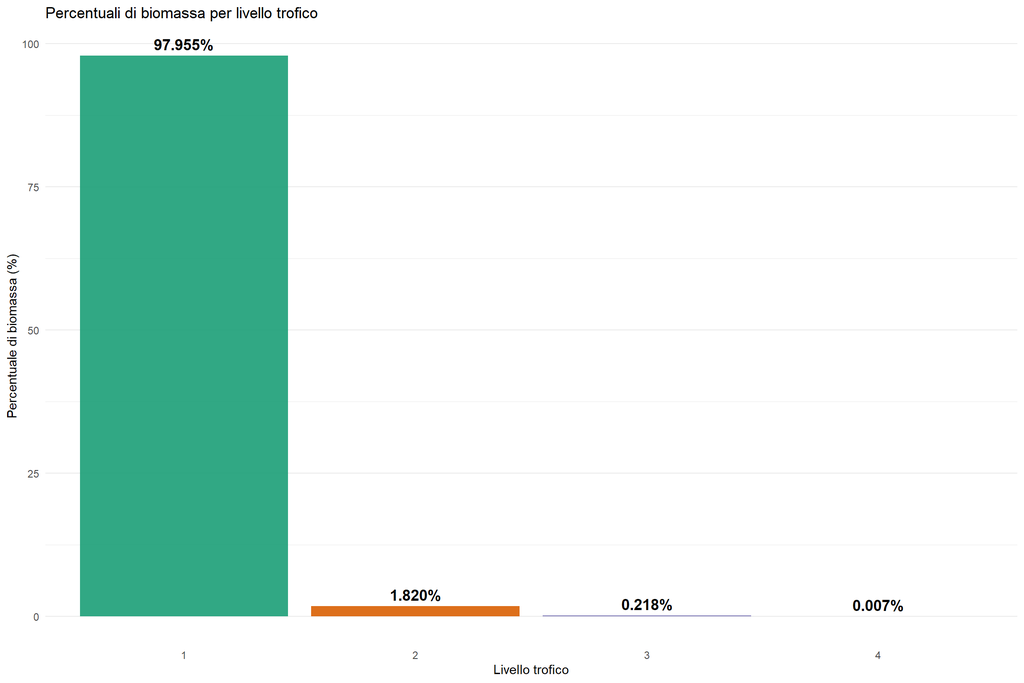

```r
df = fw_g %>%
  as_tbl_graph() %>%
  activate(nodes) %>%
  filter(eco_type == 1) %>%
  as_tibble() %>%
  group_by(trophic_lvl_int) %>%
  summarise(tot_biomass = sum(bio_mass)) %>%
  mutate(perc = tot_biomass / sum(tot_biomass) * 100)


ggplot(df, aes(x = factor(trophic_lvl_int), y = perc, fill = factor(trophic_lvl_int))) +
  geom_col(alpha = 0.9) +
  geom_text(aes(label = sprintf("%.3f%%", perc)), vjust = -0.5, fontface = "bold", size = 4.5) +
  scale_fill_manual(values = get_tl_colors()) +
  labs(
    title = "Percentuali di biomassa per livello trofico",
    x = "Livello trofico",
    y = "Percentuale di biomassa (%)"
  ) +
  theme_minimal() +
  theme(
    legend.position = "none",
    panel.grid.major.x = element_blank()
  )
```

La maggior parte della biomassa “viva” è contenuta nel primo livello trofico per un 97.96%, mentre tutti gli altri livelli, insieme, ne contengono poco più del 2%.

Inoltre si nota come la percentuale di biomassa cala all’aumentare del livello trofico. Questo rispecchia il fatto che specie di livello basso necessitano di meno energia per sopravvivere (essendo anche più piccole) ed è quindi più facile per loro proliferare.

Data la dominanza del livello trofico 1, è utile identificare quali produttori primari sono più presenti all’interno di questo livello.

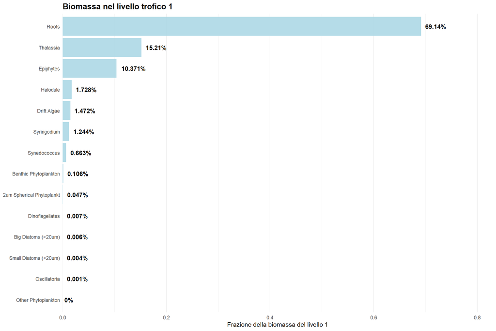

```r
# Recuperiamo la biomassa totale nel livello 1
tot_lv1_biomass = filter(biomass_tl, trophic_lvl_int == 1)$tot_biomass

# Preparazione dati
top_biomass = fw_g %>%
  as_tbl_graph() %>%
  activate(nodes) %>%
  filter(eco_type == 1 & trophic_lvl_int == 1) %>%
  mutate(bio_mass = bio_mass / tot_lv1_biomass) %>%
  select(name, bio_mass) %>%
  as_tibble()

# Usiamo reorder per riordinare le barre nella visualizzazione
ggplot(top_biomass, aes(x = reorder(name, bio_mass), y = bio_mass)) +
  geom_col(fill = "lightblue", alpha = 0.9) +
  geom_text(
    aes(label = paste0(round(bio_mass, 5)*100, "%")),
    hjust = -0.2,
    fontface = "bold"
  ) +
  coord_flip() +
  scale_y_continuous(expand = expansion(mult = c(0, 0.2))) +
  labs(
    title = "Biomassa nel livello trofico 1",
    x = NULL,
    y = "Frazione della biomassa del livello 1"
  ) +
  theme_minimal() +
  theme(
    plot.title = element_text(face = "bold", size = 14),
    panel.grid.major.y = element_blank()
  )
```

## Ecological efficiency

Viene definita **ecological efficiency** l’efficienza con cui l’energia è trasferita da un livello trofico a quello successivo.

Empiricamente solo circa il 10% dell’energia trasferita da un livello trofico viene effettivamente immagazzinata come biomassa (tessuto organico) nel livello trofico successivo. Il restante 90% dell’energia viene dissipato attraverso tre meccanismi principali:

- Respirazione cellulare: gli organismi utilizzano gran parte dell’energia per i processi metabolici, producendo calore che viene disperso nell’ambiente.
- Digestione incompleta: non tutto il materiale organico ingerito viene assimilato.
- Perdite durante il trasferimento: energia spesa nella ricerca del cibo, nella crescita, nella riproduzione e in altre attività vitali.

Analizziamo l’efficienza di questa rete trofica raggruppando l’energia sugli archi di ogni specie, da un livello trofico a un altro.

Per calcolare l’efficienza tra ogni livello successivo, sarà sufficienza calcolare:
$$\text{Ecological_efficiency}_i =
\frac{Output_{i+1}}{Input_{i}}$$

Dove:

- $Input_{i}$: indica il totale dell’energia ricevuto al livello trofico $i$
- $Output_{i+1}$: indica il totale dell’energia trasmessa al livello trofico $i+1$

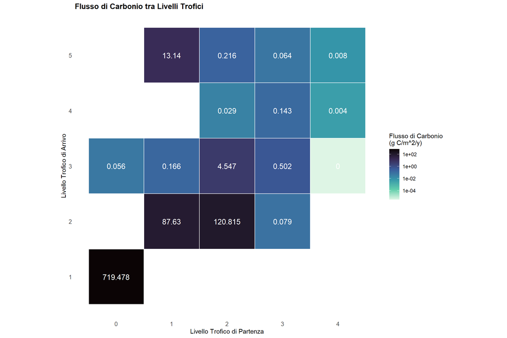

```r
# Rimuoviamo tutto ciò che non è vivo
g = fw_g_io %>%
  as_tbl_graph() %>%
  activate(nodes) %>%
  filter(!name %in% c("Respiration", "Water POC", "Benthic POC", "DOC"))

# Costruiamo il dataframe contenente la quantità di carbonio scambiato da un
# livello trofico ad un altro
energy_flow = activate(g, edges) %>%
  mutate(
    from_tl = .N()$trophic_lvl_int[from],
    to_tl = .N()$trophic_lvl_int[to]
  ) %>%
  as_tibble() %>%
  group_by(from_tl, to_tl) %>%
  summarise(carbon_flow = sum(carbon_flow), .groups = "drop")

# Heatmap del flusso di carbonio tra livelli trofici
ggplot(energy_flow, aes(x = from_tl, y = to_tl, fill = carbon_flow)) +
  geom_tile(color = "white", linewidth = 0.5) +
  geom_text(aes(label = round(carbon_flow, 3)), color = "white", size = 4.5) +
  scale_fill_viridis_c(
    option = "mako",
    trans = "log10",
    direction = -1, # Inverte la scala
    name = "Flusso di Carbonio\n(g C/m^2/y)"
  ) +
  labs(
    title = "Flusso di Carbonio tra Livelli Trofici",
    x = "Livello Trofico di Partenza",
    y = "Livello Trofico di Arrivo"
  ) +
  theme_minimal() +
  theme(
    panel.grid = element_blank(),
    plot.title = element_text(face = "bold"),
    axis.text = element_text(size = 10)
  ) +
  coord_fixed()
```

Notiamo subito che la quantità di energia trasferita cala di circa un ordine di grandezza ad ogni livello trofico (antidiagonale). E’ inoltre interessante notare che all’interno del secondo livello trofico c’è un grande scambio intra-livello di energia.

Calcoliamo l’efficienza per ogni livello trofico successivo.

```r
# Teniamo solo i flussi di energia tra livelli successivi
energy_flow = filter(energy_flow, to_tl == from_tl + 1)

# Per ogni coppia calcoliamo l'efficienza
eff = vector()
for (i in 2:nrow(energy_flow)) {
  inp_flow = energy_flow[i-1,]$carbon_flow
  out_flow = energy_flow[i,]$carbon_flow
  eff[i-1] = out_flow / inp_flow   # Il ciclo parte da indice 2, quindi [i-1]
}

eco_eff = tibble(
  "Trophic Level" = 1:4,
  "Ecological efficency %" = eff * 100
)
eco_eff
```

| Trophic Level | Ecological efficency % |
| --- | --- |
| 1 | 12.179627 |
| 2 | 5.188328 |
| 3 | 3.135331 |
| 4 | 5.769956 |

```r
round(mean(eff) * 100, 2)
```

```
## [1] 6.57
```

Risulta così che questa rete ha un’efficienza media del 6.57%.

## Potere delle specie

Essendo il potere definito come $x_i = \sum_k \frac{a_{k,i}}{x_k}$, in questo contesto considerando la matrice $\text{preda} \times \text{predatore}$, una specie è potente quando acquisisce molta energia, per quantità o flusso energetico, da prede (in-degree) con basso potere. Un’altra interpretazione potrebbe essere che una specie è potente se acquisisce molta energia da specie che ne acquisiscono poca.

```r
# create incidence matrix for a graph
make_incidence = function(g) {
  n = vcount(g)
  m = ecount(g)
  # get edges as a matrix
  E = ends(g, E(g), names = FALSE)
  B = matrix(0, nrow = n, ncol = m)
  # build incidence matrix
  for (i in 1:m) {
    B[E[i,1], i] = 1
    B[E[i,2], i] = 1
  }
  return(B)
}

regularify = function (g) {
  n = vcount(g)
  m = ecount(g)
  B = make_incidence(g)
  # objective function
  obj = rep(0, m + 1)
  # constraint matrix
  con = cbind(B, rep(-1, n))
  # direction of constraints
  dir = rep("=", n)
  # right hand side terms
  rhs = -degree(g)
  # solve the LP problem
  sol = lp("max", obj, con, dir, rhs)
  # get solution
  if (sol$status == 0) {
    s = sol$solution
    # weights
    w = s[1:m] + 1
    # weighted degree
    d = s[m+1]
  }
  # return the solution
  if (sol$status == 0) {
    return(list(weights = w, degree = d))
  }
  else {
    return(NULL)
  }
}

# Compute power x = (1/x) A
#INPUT
# A = graph adjacency matrix
# t = precision
# OUTPUT
# A list with:
# vector = power vector
# iter = number of iterations
power = function(A, t) {
  n = dim(A)[1];
  # x_2k
  x0 = rep(0, n);
  # x_2k+1
  x1 = rep(1, n);
  # x_2k+2
  x2 = rep(1, n);
  diff = 1
  eps = 1/10^t;
  iter = 0;
  while (diff > eps) {
    x0 = x1;
    x1 = x2;
    x2 = (1/x2) %*% A;
    diff = sum(abs(x2 - x0));
    iter = iter + 1;
  }
  # it holds now: alpha x2 = (1/x2) A
  alpha = ((1/x2) %*% A[,1]) / x2[1];
  # hence sqrt(alpha) * x2 = (1/(sqrt(alpha) * x2))
  x2 = sqrt(alpha) %*% x2;
  return(list(vector = as.vector(x2), iter = iter))
}
```

Verifichiamo se la matrice è regolarizzabile

```r
power_g = fw_g %>%
  as_tbl_graph() %>%
  activate(nodes) %>%
  mutate(
    trophic_lvl = ifelse(eco_type == 2, 0.0, trophic_lvl),       # Indichiamo con 0 i detriti
    trophic_lvl_int = ifelse(eco_type == 2, 0, trophic_lvl_int), # Indichiamo con 0 i detriti
  ) %>%
  as.igraph()

!is.null(regularify(power_g))
```

```
## [1] FALSE
```

La matrice non è regolarizzabile, per garantire la convergenza dell’algoritmo perturbiamo la matrice diagonalmente per calcolare il potere.

```r
B = as_adjacency_matrix(power_g, sparse = FALSE, attr="carbon_flow")
BI = B + diag(0.05, vcount(power_g))

V(power_g)$power = power(BI, 6)$vector
```

Vediamo come si distribuisce il potere tra i livelli trofici.

```r
df_mean_power = power_g %>%
  as_tbl_graph() %>%
  activate(nodes) %>%
  select(trophic_lvl_int, power) %>%
  as_tibble() %>%
  group_by(trophic_lvl_int) %>%
  summarise(avg_power = mean(power)) %>%
  arrange(trophic_lvl_int)

df_mean_power
```

| trophic_lvl_int | avg_power |
| --- | --- |
| 0 | 954.3628342 |
| 1 | 0.2236068 |
| 2 | 13.7971817 |
| 3 | 0.2674192 |
| 4 | 0.2379115 |

Notiamo che la maggior parte del potere è concentrato nei **detriti** che ricevono energia dalla maggior parte delle specie. Si nota, inoltre, che anche il livello trofico 2 sembra acquisire molta energia da specie poco potenti, questo riflette il loro consumo di specie basali.

Analizziamo ora le singole specie.

```r
power_g %>%
  as_tbl_graph() %>%
  activate(nodes) %>%
  select(name, trophic_lvl_int, power) %>%
  filter(power >= quantile(power, 0.90)) %>%
  arrange(-power) %>%
  as_tibble()
```

| name | trophic_lvl_int | power |
| --- | --- | --- |
| Benthic POC | 0 | 1429.911893 |
| Water POC | 0 | 747.047655 |
| DOC | 0 | 686.128954 |
| Water Flagellates | 2 | 229.128758 |
| Other Copepoda | 2 | 78.925315 |
| Oithona nana | 2 | 60.207874 |
| Other Zooplankton | 2 | 41.659691 |
| Water Cilitaes | 2 | 17.500402 |
| Benthic Flagellates | 2 | 13.086538 |
| Acartia Tonsa | 2 | 12.573927 |
| Herbivorous Shrimp | 2 | 10.389817 |
| Meiofauna | 2 | 9.730087 |
| Bivalves | 2 | 5.729925 |

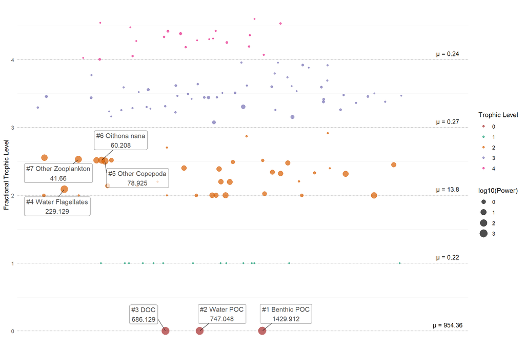

```r
# Preparazione dati
power_g = power_g %>%
  as_tbl_graph() %>%
  activate(nodes) %>%
  mutate(
    is_high_power = power >= quantile(power, 0.95), # flag per indicare specie potente
    power_label = paste0("#", rank(-power), " ", name, "\n", round(power, 3)) # Etichetta: # <rank> <name> \n <power>
  )

coords = layout_igraph_constrained_stress(
  power_g,
  coord = V(power_g)$trophic_lvl,
  fixdim = "y"
)

ggraph(power_g, layout = "manual", x = coords$x, y = coords$y) +
  geom_hline(
    data = df_mean_power,
    aes(yintercept = trophic_lvl_int),
    linetype = "dashed",
    alpha = 0.2,
  ) +
  geom_node_point(
    aes(color = factor(trophic_lvl_int), size = log10(power)), # log per visualizzare meglio
    alpha = 0.7
  ) +
  geom_node_label(
    aes(filter = is_high_power, label = power_label),
    alpha = 0.7,
    repel = TRUE,
    box.padding = 0.8
  ) +
  # Testo sopra a hline
  geom_text(
    data = df_mean_power,
    aes(
      x = max(coords$x) * 1.2,
      y = trophic_lvl_int,
      label = paste0("μ = ", round(avg_power, 2))
    ),
    size = 3.5,
    vjust = -0.8
  ) +
  scale_color_manual(
    values = c("brown", get_tl_colors()),
    name = "Trophic Level"
  ) +
  scale_y_continuous(name = "Fractional Trophic Level") +
  scale_size_continuous(name = "log10(Power)") +
  theme_minimal() +
  theme(
    axis.title.x = element_blank(),
    axis.text.x  = element_blank(),
    axis.ticks.x = element_blank(),
    panel.grid.major.x = element_blank(),
    panel.grid.minor.x = element_blank()
  )
```

## Specie centrali

Ci concentriamo ora a studiare quali specie risultano maggiormente centrali all’interno dell’ecosistema. Per fare questo **invertiamo la direzione degli archi**, in quanto siamo interessati a quali specie sono vitali nella dieta di altri specie. Consideriamo il grafo non pesato per questa analisi.

> In questa analisi non verranno considerati i detriti, considerando solo le specie “vive”. Rimuovendo POC e DOC, un solo nodo “Roots” si disconnette dal grafo e questo verrà rimosso con `filter(!node_is_isolated())`.

In questa analisi useremo le seguenti misure di centralità:

- **betweeness**: indica quali specie sono le più ricorrenti nei cammini minimi;
- **harmonic**: (a differenza della closeness $\frac{1}{d(u,v)} = 0$ se non esiste un cammino tra $u$ e $v$). Indica quali specie sono le più vicine alle altre
- **page rank**: misura l’importanza di una specie basandosi sull’importanza delle specie che la consumano/utilizzano

### Analisi trophic level

Iniziamo osservando come si comportano le misure di centralità tra i livelli trofici.

```r
# Manteniamo solo le specie "vive" e calcoliamo le misure di centralità
centr_g = fw_g %>%
  reverse_edges() %>%
  as_tbl_graph() %>%
  activate(nodes) %>%
  filter(!name %in% c("Benthic POC", "Water POC", "DOC")) %>%
  filter(!node_is_isolated()) %>%
  mutate(
    harm = centrality_harmonic(mode = "in", normalized = TRUE),
    betw = centrality_betweenness(directed = TRUE, normalized = TRUE),
    prank = centrality_pagerank()
  ) %>%
  as.igraph()

df_mean_centr = centr_g %>%
  as_tbl_graph() %>%
  activate(nodes) %>%
  as_tibble() %>%
  select(name, trophic_lvl, trophic_lvl_int, betw, harm, prank) %>%
  group_by(trophic_lvl_int) %>%
  summarise(
    avg_betw = mean(betw),
    avg_harm = mean(harm),
    avg_prank = mean(prank)
  ) %>%
  arrange(trophic_lvl_int)
df_mean_centr
```

| trophic_lvl_int | avg_betw | avg_harm | avg_prank |
| --- | --- | --- | --- |
| 1 | 0.0000000 | 0.3988462 | 0.0202433 |
| 2 | 0.0035519 | 0.3443393 | 0.0108107 |
| 3 | 0.0043417 | 0.1865251 | 0.0052677 |
| 4 | 0.0003094 | 0.0187500 | 0.0034093 |

La **betweeness**, come potevamo aspettarci, è particolarmente bassa nei livelli estremi (1 e 4) in quanto le specie in questi livelli saranno specialmente nodi di inizio o fine nella rete.

Per quanto riguarda la **harmonic** centrality si nota che all’aumentare della livello trofico, questa cala.

```r
cor(V(centr_g)$harm, V(centr_g)$trophic_lvl)
```

```
## [1] -0.6797157
```

Calcolando la correlazione tra harmonic centrality e livello trofico, risulta una correlazione negativa. Questo risultato è spiegato dal fatto che ogni specie ha, tendenzialmente, un cammino con i livelli più bassi. Salendo di livello meno specie hanno cammini con i livelli sottostanti pesando $0$ nel calcolo della metrica.

Infine il **page rank**, ha un comportamento simile alla harmonic centrality, questo è dovuto al fatto che ogni specie deve avere una fonte primaria di energia che sono i produttori dei livelli base, questi produttori non “disperdono” il page rank in quanto nodi terminali.

```r
cor(V(centr_g)$prank, V(centr_g)$trophic_lvl)
```

```
## [1] -0.5990347
```

### Analisi singole specie

Analizziamo ora le misure di centralità per le singole specie.

```r
coords = layout_igraph_constrained_stress(
  centr_g,
  coord = V(centr_g)$trophic_lvl,
  fixdim = "y"
)

# Per ogni misura di centralità si imposta:
# - flag: is_high_<centr_name>
# - etichetta: # <rank> <name> \n <centr_value>
centr_g = centr_g %>%
  as_tbl_graph() %>%
  activate(nodes) %>%
  mutate(
    # Betweeness
    is_high_betw = betw >= quantile(betw, 0.95),
    betw_label = paste0("#", rank(-betw), " ", name, "\n", round(betw, 3)),

    # Harmonic
    is_high_harm = harm >= quantile(harm, 0.95),
    harm_label = paste0("#", rank(-harm), " ", name, "\n", round(harm, 3)),

    # PageRank
    is_high_prank = prank >= quantile(prank, 0.95),
    prank_label = paste0("#", rank(-prank), " ", name, "\n", round(prank, 3)),
  )
```

#### Betweeness

Analizziamo la betweeness sulle singole specie.

```r
centr_g %>%
  activate(nodes) %>%
  filter(is_high_betw) %>%
  select(name, trophic_lvl_int, betw) %>%
  arrange(-betw) %>%
  as_tibble()
```

| name | trophic_lvl_int | betw |
| --- | --- | --- |
| Predatory Gastropods | 3 | 0.0285971 |
| Echinoderma | 2 | 0.0225531 |
| Predatory Polychaetes | 3 | 0.0189589 |
| Other Cnidaridae | 3 | 0.0183825 |
| Other Demersal Fishes | 2 | 0.0183040 |
| Predatory Shrimp | 3 | 0.0162558 |
| Eels | 3 | 0.0161395 |

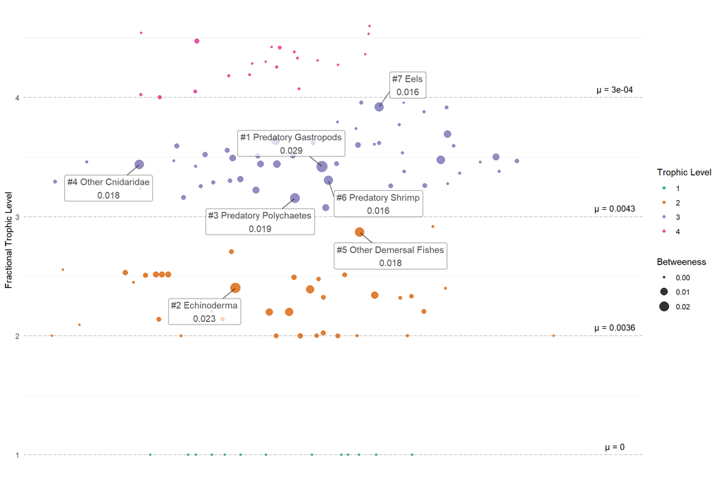

```r
ggraph(centr_g, layout = "manual", x = coords$x, y = coords$y) +
  geom_hline(
    data = df_mean_centr,
    aes(yintercept = trophic_lvl_int),
    linetype = "dashed",
    alpha = 0.2,
  ) +
  geom_node_point(
    aes(color = factor(trophic_lvl_int), size = betw),
    alpha = 0.8
  ) +
  geom_node_label(
    aes(filter = is_high_betw, label = betw_label),
    alpha = 0.7,
    repel = TRUE,
    box.padding = 0.8
  ) +
  geom_text(
    data = df_mean_centr,
    aes(
      x = max(coords$x) * 1.2,
      y = trophic_lvl_int,
      label = paste0("μ = ", round(avg_betw, 4))
    ),
    size = 3.5,
    vjust = -0.8
  ) +
  scale_color_manual(values = get_tl_colors(), name = "Trophic Level") +
  scale_y_continuous(name = "Fractional Trophic Level") +
  scale_size_continuous(name = "Betweeness") +
  theme_minimal() +
  theme(
    axis.title.x = element_blank(),
    axis.text.x  = element_blank(),
    axis.ticks.x = element_blank(),
    panel.grid.major.x = element_blank(),
    panel.grid.minor.x = element_blank()
  )
```

I risultati rispecchiano l’analisi aggrata.

#### Harmonic

Analizziamo la harmonic centrality sulle singole specie.

```r
centr_g %>%
  activate(nodes) %>%
  filter(is_high_harm) %>%
  select(name, trophic_lvl_int, harm) %>%
  arrange(-harm) %>%
  as_tibble()
```

| name | trophic_lvl_int | harm |
| --- | --- | --- |
| Herbivorous Shrimp | 2 | 0.5548611 |
| Predatory Shrimp | 3 | 0.5506944 |
| Pink Shrimp | 2 | 0.5087500 |
| Synedococcus | 1 | 0.4986111 |
| Bivalves | 2 | 0.4958333 |
| Omnivorous Crabs | 2 | 0.4873611 |
| Detritivorous Amphipods | 2 | 0.4708333 |

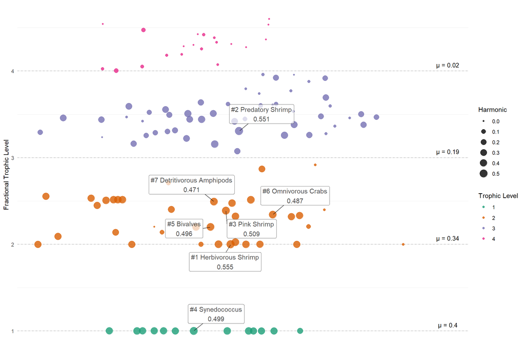

```r
ggraph(centr_g, layout = "manual", x = coords$x, y = coords$y) +
  geom_hline(
    data = df_mean_centr,
    aes(yintercept = trophic_lvl_int),
    linetype = "dashed",
    alpha = 0.2,
  ) +
  geom_node_point(
    aes(color = factor(trophic_lvl_int), size = harm),
    alpha = 0.8
  ) +
  geom_node_label(
    aes(filter = is_high_harm, label = harm_label),
    alpha = 0.7,
    repel = TRUE,
    box.padding = 0.8
  ) +
  geom_text(
    data = df_mean_centr,
    aes(
      x = max(coords$x) * 1.2,
      y = trophic_lvl_int,
      label = paste0("μ = ", round(avg_harm, 2))
    ),
    size = 3.5,
    vjust = -0.8
  ) +
  scale_color_manual(values = get_tl_colors(), name = "Trophic Level") +
  scale_y_continuous(name = "Fractional Trophic Level") +
  scale_size_continuous(name = "Harmonic") +
  theme_minimal() +
  theme(
    axis.title.x = element_blank(),
    axis.text.x  = element_blank(),
    axis.ticks.x = element_blank(),
    panel.grid.major.x = element_blank(),
    panel.grid.minor.x = element_blank()
  )
```

I risultati rispecchiano l’analisi aggrata, eccezzione fatta per i “Predatory Shrimp” di livello trofico 3. Questo risultato potrebbe essere dovuto al fatto che questa specie viene sfruttata da molti predatori e a sua volta si nutre di molte specie di livello inferiore.

#### Page rank

Infine analizziamo il page rank per le singole specie.

```r
centr_g %>%
  activate(nodes) %>%
  filter(is_high_prank) %>%
  select(name, trophic_lvl_int, prank) %>%
  arrange(-prank) %>%
  as_tibble()
```

| name | trophic_lvl_int | prank |
| --- | --- | --- |
| Benthic Phytoplankton | 1 | 0.0705527 |
| Epiphytes | 1 | 0.0367717 |
| Synedococcus | 1 | 0.0334800 |
| Benthic Flagellates | 2 | 0.0309407 |
| Benthic Ciliates | 2 | 0.0217128 |
| Herbivorous Shrimp | 2 | 0.0171770 |
| 2um Spherical Phytoplankt | 1 | 0.0170146 |

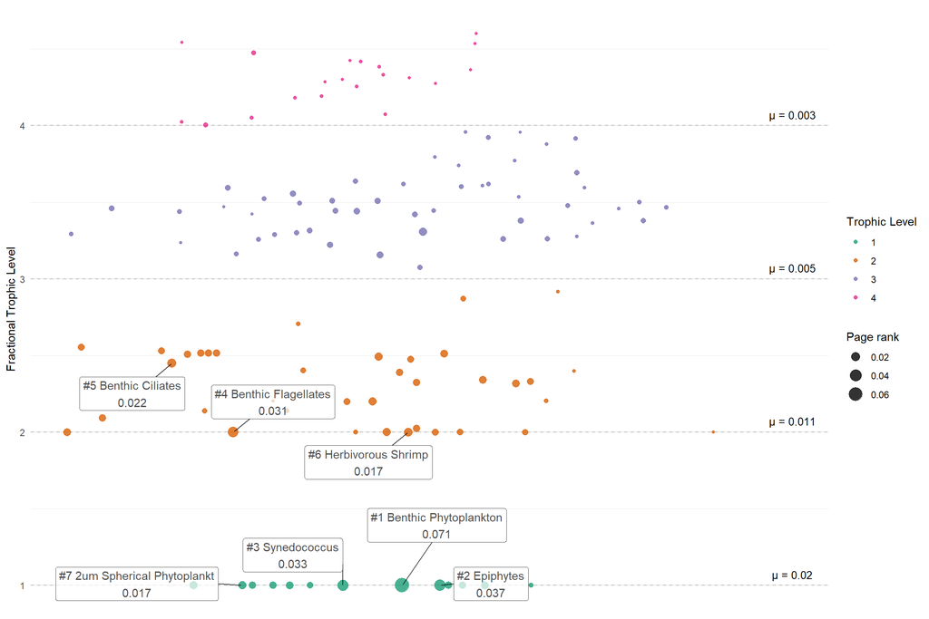

```r
ggraph(centr_g, layout = "manual", x = coords$x, y = coords$y) +
  geom_hline(
    data = df_mean_centr,
    aes(yintercept = trophic_lvl_int),
    linetype = "dashed",
    alpha = 0.2,
  ) +
  geom_node_point(
    aes(color = factor(trophic_lvl_int), size = prank),
    alpha = 0.8
  ) +
  geom_node_label(
    aes(filter = is_high_prank, label = prank_label),
    alpha = 0.7,
    repel = TRUE,
    box.padding = 0.8
  ) +
  geom_text(
    data = df_mean_centr,
    aes(
      x = max(coords$x) * 1.2,
      y = trophic_lvl_int,
      label = paste0("μ = ", round(avg_prank, 3))
    ),
    size = 3.5,
    vjust = -0.8
  ) +
  scale_color_manual(values = get_tl_colors(), name = "Trophic Level") +
  scale_y_continuous(name = "Fractional Trophic Level") +
  scale_size_continuous(name = "Page rank") +
  theme_minimal() +
  theme(
    axis.title.x = element_blank(),
    axis.text.x  = element_blank(),
    axis.ticks.x = element_blank(),
    panel.grid.major.x = element_blank(),
    panel.grid.minor.x = element_blank()
  )
```

I risultati sono coerenti con l’analisi aggragata precedente ponendo come specie di maggior importanza specie basali.

## Analisi dei gradi

Ci concentriamo ora a studiare i gradi della food web.

Ricordiamo che:

- in-degree: indica il numero di specie che preda
- out-degree: indica il numero di specie da cui è predata

Già solo con i gradi entranti e uscenti siamo in grado di estrarre quali specie sono in cima alla catena alimentare e quali invece sono alla base. Possiamo considerare i gradi entranti e uscenti come metriche per identificare:

- **super predatori** predano altri e non sono quasi mai predati
- **super preda**: produttori primari che vengono solo predati

```r
deg_df = fw_g %>%
  as_tbl_graph() %>%
  activate(nodes) %>%
  filter(eco_type == 1) %>%
  filter(!node_is_isolated()) %>%
  mutate(
    in_degree = centrality_degree(mode = "in"),
    out_degree = centrality_degree(mode = "out"),
    total_degree = centrality_degree(mode = "all"),
  ) %>%
  as_tibble()
```

```r
# super predatori
deg_df %>%
  filter(out_degree == 0) %>% # specie con nessun predatore
  arrange(-in_degree) %>%
  select(
    name,
    in_degree, out_degree,
    trophic_lvl
  ) %>%
  head(10)
```

| name | in_degree | out_degree | trophic_lvl |
| --- | --- | --- | --- |
| Crocodiles | 39 | 0 | 4.363022 |
| Predatory Ducks | 37 | 0 | 4.301262 |
| Raptors | 37 | 0 | 4.601776 |
| Greeb | 36 | 0 | 4.286215 |
| Dolphin | 34 | 0 | 4.424527 |
| Loon | 33 | 0 | 4.310491 |
| Grouper | 30 | 0 | 3.957014 |
| Sharks | 28 | 0 | 4.534386 |
| Kingfisher | 19 | 0 | 4.274697 |
| Manatee | 19 | 0 | 2.203248 |

Per quanto riguarda le super prede, analogamente a sopra, avremo specie di livello trofico 1 e 2. Filtriamo quindi le specie di livello trofico 1 che non predano alcuna specie. E estraiamo le specie con livello 2 o superiore.

```r
# super prede
# nota: vengono rimosse le specie che sono solo produttori, quindi livello trofico uguale a 1 (come ad esempio le piante o phytoplankton)
deg_df %>%
  arrange(-out_degree, in_degree) %>%
  filter(trophic_lvl_int != 1) %>%
  select(
    name,
    in_degree, out_degree,
    trophic_lvl
  ) %>%
  head(10)
```

| name | in_degree | out_degree | trophic_lvl |
| --- | --- | --- | --- |
| Herbivorous Shrimp | 2 | 60 | 2.000000 |
| Predatory Shrimp | 13 | 60 | 3.307168 |
| Pink Shrimp | 15 | 54 | 2.390210 |
| Omnivorous Crabs | 11 | 45 | 2.342303 |
| Bivalves | 9 | 43 | 2.199143 |
| Detritivorous Gastropods | 5 | 37 | 2.024430 |
| Goldspotted killifish | 22 | 37 | 3.440137 |
| Detritivorous Amphipods | 4 | 36 | 2.491564 |
| Herbivorous Amphipods | 5 | 35 | 2.000000 |
| Suspension Feeding Polych | 11 | 35 | 2.200630 |

Notiamo che tra le prime 10 super prede abbiamo:

- shrimp
- detritivori (Detritivorous)

A questo punto possiamo chiderci come si distribuiscono i gradi di predatori (in-degree) e prede (out-degree)

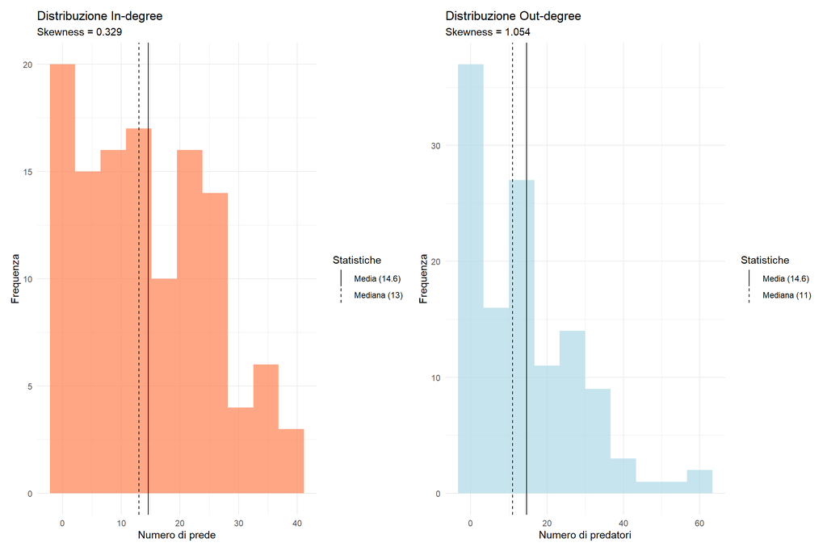

```r
skewness = function(x) mean( (x - mean(x))^3 ) / sd(x)^3

# Statistiche per in-degree
in_deg_mean = mean(deg_df$in_degree)
in_deg_median = median(deg_df$in_degree)
in_deg_skew = skewness(deg_df$in_degree)

# Label per legenda
in_deg_mean_label = paste0("Media (", round(in_deg_mean, 2), ")")
in_deg_median_label = paste0("Mediana (", round(in_deg_median, 2), ")")

# Distribuzione in-degree
in_deg_plot = ggplot(deg_df) +
  geom_histogram(aes(in_degree), bins=10, fill="coral", alpha=0.7) +
  geom_vline(aes(xintercept = in_deg_mean, linetype = in_deg_mean_label)) +
  geom_vline(aes(xintercept = in_deg_median, linetype = in_deg_median_label)) +
  scale_linetype_manual(
    name = "Statistiche",
    values = c("solid", "dashed")
  ) +
  labs(
    title = "Distribuzione In-degree",
    subtitle = paste0("Skewness = ", round(in_deg_skew, 3)),
    x = "Numero di prede",
    y = "Frequenza"
  ) +
  theme_minimal()

# Statistiche per out-degree
out_deg_mean = mean(deg_df$out_degree)
out_deg_median = median(deg_df$out_degree)
out_deg_skew = skewness(deg_df$out_degree)

# Label per legenda
out_deg_mean_label = paste0("Media (", round(out_deg_mean, 2), ")")
out_deg_median_label = paste0("Mediana (", round(out_deg_median, 2), ")")

# Distribuzione out-degree
out_deg_plot = ggplot(deg_df) +
  geom_histogram(aes(out_degree), bins=10, fill="lightblue", alpha=0.7) +
  geom_vline(aes(xintercept = out_deg_mean, linetype = out_deg_mean_label)) +
  geom_vline(aes(xintercept = out_deg_median, linetype = out_deg_median_label)) +
  scale_linetype_manual(
    name = "Statistiche",
    values = c("solid", "dashed")
  ) +
  labs(
    title = "Distribuzione Out-degree",
    subtitle = paste0("Skewness = ", round(out_deg_skew, 3)),
    x = "Numero di predatori",
    y = "Frequenza"
  ) +
  theme_minimal()

# Visualizza affiancati
in_deg_plot + out_deg_plot
```

La distribuzione dei gradi entranti, numero di specie che ha a disposizione un predatore, risulta tendenzialmente uniforme con un leggera skewness, questo viene rilevato anche dal calcolo della skewness con un valore di 0.32. Mentre invece la distribuzione dei gradi uscenti, numero di predatori che predano una preda, sembra seguire una distribuzione a coda lunga, in questo caso infatti la skweness riporta un valore di 1.05.

Dai grafici delle distribuzioni possiamo dire che all’interno di questo ecosistema:

- sono presenti predatori sia specialisti (in-degree basso) che generalisti (in-degree alto);
- molte prede sono consumate da pochi predatori, mentre poche prede sono consumate da molti.

## Connettività

Ci concentriamo ora a studiare la food web globalmente.

```r
# connectance calcola la "connectance" di una rete trofica (food web)
# La connectance misura la proporzione di collegamenti trofici realizzati
# rispetto a tutti i possibili collegamenti tra le specie
#
# INPUT
# g: grafo della food web
# directed: se TRUE calcola la directed connectance (default),
#           se FALSE calcola l'interactive connectance
#
# OUTPUT
# connectance: valore di connectance (compreso tra 0 e 1)
#
# FORMULE
# Directed connectance: C = L / S^2
# Interactive connectance: C = 2L / [S(S-1)]
# dove L = numero di collegamenti, S = numero di specie
connectance = function(g, directed = TRUE) {
  # defined from https://www.pnas.org/doi/10.1073/pnas.192407699
  # from page 5 of https://indico.ictp.it/event/a08145/session/28/contribution/17/material/0/1.pdf

  n_species = vcount(g)
  n_links = ecount(g)

  if (directed) {
    # Directed connectance
    connectance = n_links / (n_species^2)
  } else {
    # Interactive connectance (collegamenti non direzionali)
    connectance = (2 * n_links) / (n_species * (n_species - 1))
  }

  return(connectance)
}
```

Una prima misura per stabilità di una food web contro la perdita di specie è la **connectance**, definita come:

$$C = \frac{L}{S^2}$$
dove:

- $L$: numero di link
- $S$: numero di specie nella rete

Questa misura compresa tra 0 e 1, rappresenta la frazione di tutti i possibili legami di alimentazione che sono effetivamente presenti rispetto a tutti quelli realizzabili.

```r
# g = fw_g %>%
#   as_tbl_graph() %>%
#   activate(nodes) %>%
#   filter(eco_type == 1) %>%
#   as.igraph()

round(connectance(fw_g), 2)
```

```
## [1] 0.12
```

La nostra rete risulta con una connectance di 0.12, sintomo di una rete con robustezza moderata.

Analizziamo ora le componenti fortemente connesse all’interno della rete. Iniziamo mantenendo anche i detriti.

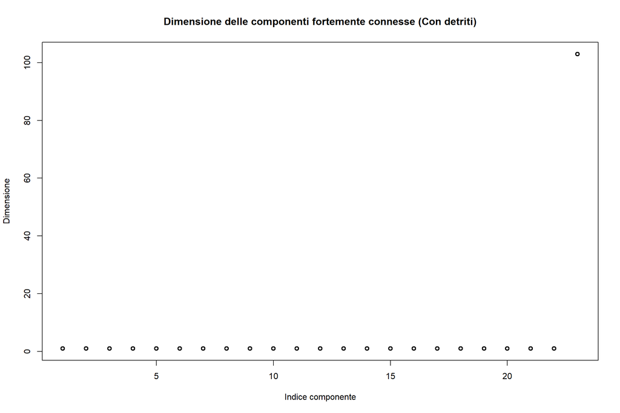

```r
scc_with_detritus = components(fw_g, mode = "strong")

plot(scc_with_detritus$csize,
     xlab = "Indice componente",
     ylab = "Dimensione",
     main = "Dimensione delle componenti fortemente connesse (Con detriti)",
     lwd = 2)
```

Mantenendo i detriti troviamo una SCC che comprende la maggior parte dei nodi. Visualizziamo quali nodi rimangono fuori dalla SCC.

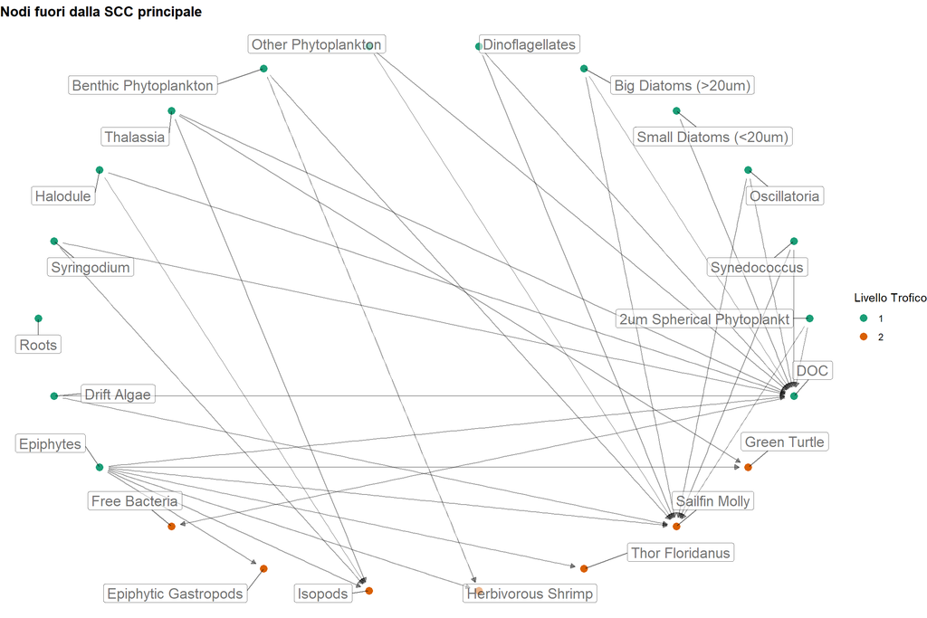

```r
largest_scc_id = which.max(scc_with_detritus$csize)
nodes_outside_scc = which(scc_with_detritus$membership != largest_scc_id)
nodes_outside_names = names(nodes_outside_scc)

fw_g %>%
  as_tbl_graph() %>%
  activate(nodes) %>%
  filter(name %in% nodes_outside_names) %>%
  ggraph(layout = 'circle') +
  geom_edge_link(alpha = 0.4,
                 arrow = arrow(length = unit(1.7, 'mm'), type = "closed"),
                 start_cap = circle(3, 'mm'),
                 end_cap = circle(3, 'mm')) +
  geom_node_point(aes(color = factor(trophic_lvl_int)), size = 3) +
  geom_node_label(
    aes(label = name),
    size = 4.8,
    repel = TRUE,
    alpha = 0.55,
    box.padding = 1, # padding attorno alla box
    # min.segment.length = 3 # evita di creare la linea di collegamento
  ) +
  scale_color_manual(values = get_tl_colors(),
                     name = "Livello Trofico") +
  labs(title = "Nodi fuori dalla SCC principale") +
  theme_void() +
  theme(
    plot.title = element_text(face = "bold"),
    legend.position = "right"
  )
```

Emerge che i produttori basali (livello trofico 1) sono fuori dalla SCC in quanto sono sorgenti unidirezionali che non ricevono flussi di ritorno, la loro fonte di energia è principalmente il Sole. E’ però interessante notare che ci siano alcune specie di livello 2 che non fanno parte delle SCC.  
Cosa caratterizza queste specie?

```r
fw_g %>%
  as_tbl_graph() %>%
  activate(nodes) %>%
  filter(name %in% nodes_outside_names & trophic_lvl_int > 1) %>%
  select(name, trophic_lvl, trophic_lvl_int) %>%
  as_tibble()
```

| name | trophic_lvl | trophic_lvl_int |
| --- | --- | --- |
| Free Bacteria | 2 | 2 |
| Epiphytic Gastropods | 2 | 2 |
| Isopods | 2 | 2 |
| Herbivorous Shrimp | 2 | 2 |
| Thor Floridanus | 2 | 2 |
| Sailfin Molly | 2 | 2 |
| Green Turtle | 2 | 2 |

Queste specie sono puramente erbivore (livello trofico = 2) e ricavano energia solo dal livello precedente, non si reintroducono all’interno della SCC. La specializzazione degli erbivori, potrebbe indicare vulnerabilità all’estinzione. Tuttavia la grande disponibilità di biomassa al primo livello (come visto precedentemente 98%) garantisce un’abbondanza di risorse. La vulnerabilità di queste specie è quindi dovuta a altri fattori:

- distruzione degli habitat
- cambiamenti qualitativi dell’ambiente
- disturbi antropici: pesca, inquinamento, cambiamento climatico

Visualizziamo nel dettaglio prede e predatori della Green Turtle.

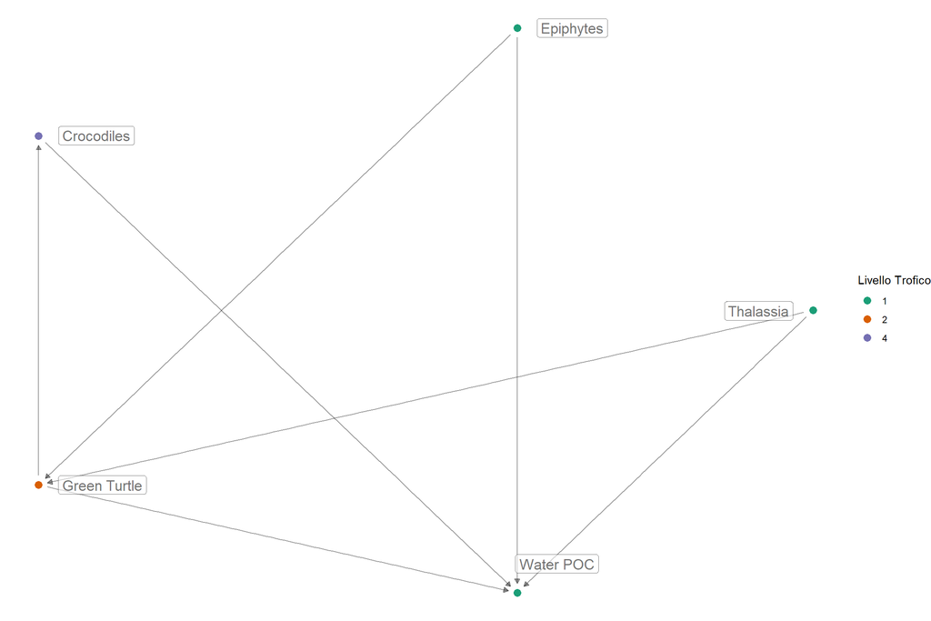

```r
green_turtle_id = which(V(fw_g)$name == "Green Turtle")
neighbors_all = neighbors(fw_g, green_turtle_id, mode = "all")
nodes_to_keep = c(green_turtle_id, neighbors_all)

induced_subgraph(fw_g, nodes_to_keep) %>%
  as_tbl_graph() %>%
  activate(nodes) %>%
  ggraph(layout = "circle") +
  geom_edge_fan(alpha = 0.4,
                 arrow = arrow(length = unit(1.7, 'mm'), type = "closed"),
                 start_cap = circle(3, 'mm'),
                 end_cap = circle(3, 'mm')) +
  geom_node_point(aes(color = factor(trophic_lvl_int)), size = 3) +
  geom_node_label(
    aes(label = name),
    size = 4.8,
    repel = TRUE,
    alpha = 0.55,
    box.padding = 1.2, # padding attorno alla box
    min.segment.length = 3 # evita di creare la linea di collegamento
  ) +
  scale_color_manual(values = get_tl_colors(),
                     name = "Livello Trofico") +
  theme_void()
```

Recuperiamo le SCC rimuovendo i detriti.

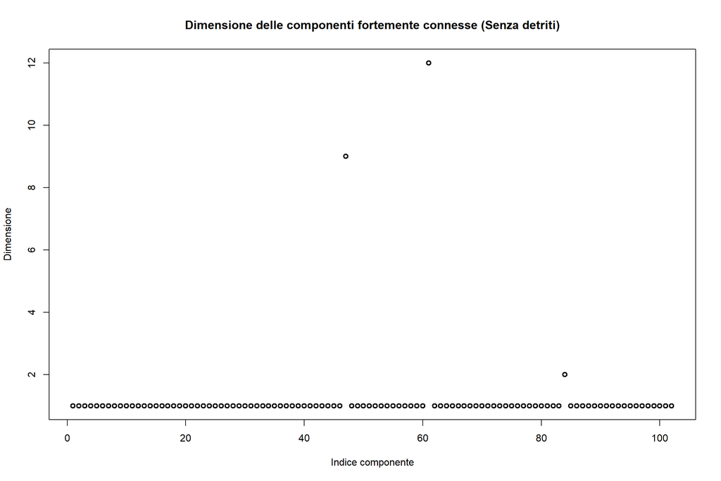

```r
g = fw_g %>%
  as_tbl_graph() %>%
  activate(nodes) %>%
  filter(eco_type == 1) %>%
  as.igraph()

scc_no_detritus = components(g, mode = "strong")

plot(scc_no_detritus$csize,
     xlab = "Indice componente",
     ylab = "Dimensione",
     main = "Dimensione delle componenti fortemente connesse (Senza detriti)",
     lwd = 2)
```

Si nota che rimuovendo i detriti la rete diventa sconnessa con piccoli cicli trofici isolati. Questo mostra quanto sia importante il ruolo dei detriti all’interno di un ecosistema in quanto questa energia non viene sprecata ma reintrodotta nel sistema.

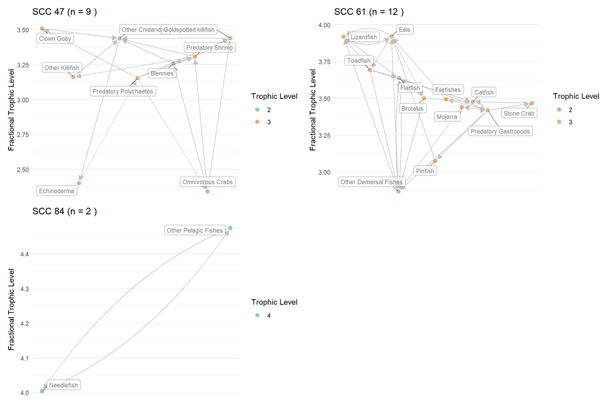

```r
# Trovo le SCC con dimensione > 1
sccs_id = which(scc_no_detritus$csize != 1)

# Creo una lista di plot, uno per ogni SCC
plot_list = lapply(sccs_id, function(scc_idx) {
  # Recupera nodi di questa SCC
  species_in_scc = which(scc_no_detritus$membership == scc_idx)

  # Creo il sottografo per questa SCC
  fw_g_scc = induced_subgraph(fw_g, species_in_scc)

  # Calcolo il layout + plot
  coords = layout_igraph_constrained_stress(
    fw_g_scc,
    coord = V(fw_g_scc)$trophic_lvl,
    fixdim = "y"
  )

  plot = ggraph(fw_g_scc, layout = "manual", x = coords$x, y = coords$y) +
    geom_edge_fan(
      alpha = 0.9,
      edge_colour = "grey",
      arrow = arrow(length = unit(2.5, 'mm'), type = "closed"),
      start_cap = circle(1.5, 'mm'),
      end_cap = circle(1.5, 'mm')
    ) +
    geom_node_point(aes(color = factor(trophic_lvl_int)), size = 2.3, alpha=0.5) +
    geom_node_label(
      aes(label = name),
      size = 3,
      repel = TRUE,
      max.overlaps = 20,
      alpha = 0.5,
      box.padding = 0.4
    ) +
    scale_color_manual(values = get_tl_colors(), name = "Trophic Level") +
    scale_y_continuous(name = "Fractional Trophic Level") +
    ggtitle(paste("SCC", scc_idx, "(n =", length(species_in_scc), ")")) +
    theme_minimal() +
    theme(
      axis.title.x = element_blank(),
      axis.text.x  = element_blank(),
      axis.ticks.x = element_blank(),
      panel.grid.major.x = element_blank(),
      panel.grid.minor.x = element_blank()
    )
  return(plot)
})

# Combino tutti i plot affiancati
wrap_plots(plot_list, nrow = 2)
```

## Comunità

L’analisi delle comunità all’interno della food web rilevano **compartimenti**, ovvero sotto gruppi di specie che interagiscono fortemente tra di loro. Questi compartimenti possono essere visti come sotto food web. Teoricamente ogni compartimento risulta stabile rispetto agli altri, ovvero un’alterazione di un compartimento (es. estinzione di una specie) non dovrebbe influenzare significativamente gli altri.

Per eseguire questa analisi si procederà con la seguente pipeline:

1. Esecuzione di diversi metodi di calcolo delle comunità (Louvain, Edge Betweenness, Fast Greedy, Label Propagation, etc…).
2. Scelta di due algoritmi che producono maggiore modularità.
3. Analisi dei livelli trofici all’interno delle comunità.

```r
# Preparazione grafo
g = fw_g %>%
  as_tbl_graph() %>%
  activate(nodes) %>%
  filter(eco_type == 1) %>%
  filter(!node_is_isolated()) %>%
  as.igraph() %>%
  as_undirected(mode = "collapse")

methods = list(
  "Louvain" = cluster_louvain,
  "Edge Betweenness" = cluster_edge_betweenness,
  "Fast Greedy" = cluster_fast_greedy,
  "Label Propagation" = cluster_label_prop,
  "Leading Eigenvector" = cluster_leading_eigen,
  "Walktrap" = cluster_walktrap,
  "Spinglass" = function(graph) cluster_spinglass(graph, spins = 10),
  "Infomap" = cluster_infomap
  # "Optimal" = cluster_optimal
)

# Compute modularity for each method
results = data.frame(
  Method = character(),
  Modularity = numeric(),
  Length = numeric(),
  stringsAsFactors = FALSE
)

for (method in names(methods)) {
  tryCatch({
    # Set seed for reproducibility
    set.seed(67)

    # Detect communities
    communities = methods[[method]](g)

    # Compute modularity
    modularity_value = modularity(communities)

    # Store the result
    results = rbind(results, data.frame(
      Method = method,
      Modularity = modularity_value,
      Length = length(communities)
    ))

    # Store result in graph
    g = set_vertex_attr(g, method, value = membership(communities))

  }, error = function(e) {
    # Handle any errors (e.g., if a method is not applicable)
    cat("Error with method:", method, "\n")
  })
}

# Sort results by modularity in decreasing order
results[order(-results$Modularity), ]
```

|  | Method | Modularity | Length |
| --- | --- | --- | --- |
| 7 | Spinglass | 0.1947463 | 4 |
| 1 | Louvain | 0.1924205 | 6 |
| 3 | Fast Greedy | 0.1561395 | 4 |
| 5 | Leading Eigenvector | 0.1447770 | 3 |
| 6 | Walktrap | 0.1045574 | 2 |
| 2 | Edge Betweenness | 0.0456751 | 58 |
| 4 | Label Propagation | 0.0000000 | 1 |
| 8 | Infomap | 0.0000000 | 1 |

Dall’analisi delle comunità, risulta che i metodi “Spinglass” e “Louvain” producono maggiore modularità. Nonostante il numero di comunità sia differente la modularità è molto simile. Verifichiamo, ora come sono distribuiti i livelli trofici tra le comunità.

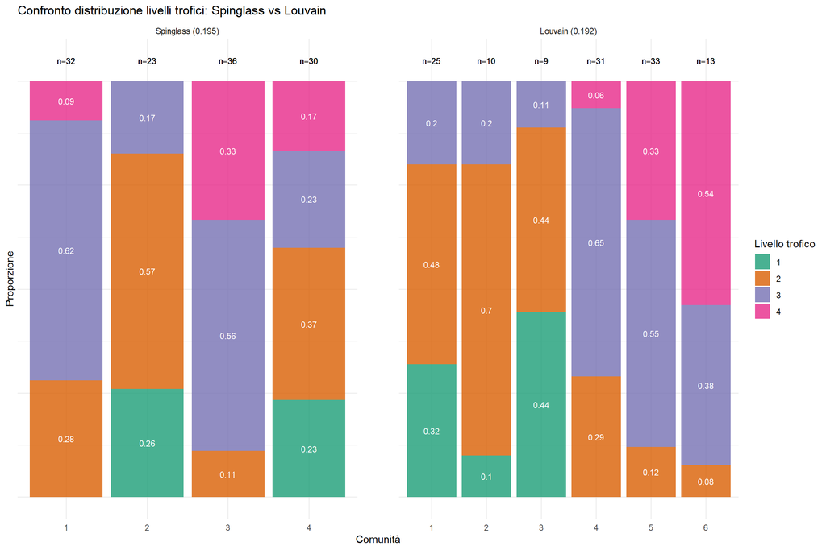

```r
df = g %>%
  as_tbl_graph() %>%
  activate(nodes) %>%
  select(trophic_lvl_int, Spinglass, Louvain) %>%
  as_tibble() %>%
  pivot_longer(
    cols = c(Spinglass, Louvain),
    names_to = "algorithm",
    values_to = "community"
  )

# Esraggo modularità dai due metodi migliori
spin_mod = results$Modularity[which(results$Method == "Spinglass")]
louv_mod = results$Modularity[which(results$Method == "Louvain")]

df %>%
  mutate(algorithm = factor(
    algorithm,
    levels = c("Spinglass", "Louvain"), # Diamo ordine di apparizione
    labels = c(                             # Aggiungiamo etichette personalizzate
      paste0("Spinglass (", round(spin_mod, 3),")"),
      paste0("Louvain (", round(louv_mod, 3),")")
    )
  )) %>%
  count(algorithm, community, trophic_lvl_int) %>%
  group_by(algorithm, community) %>%
  mutate(
    perc = n / sum(n),
    size = sum(n)
  ) %>%
  ggplot(aes(fill = factor(trophic_lvl_int), x = factor(community), y = perc)) +
    geom_col(position = position_stack(reverse = TRUE), alpha = 0.8) +
    geom_text(aes(x = factor(community), y = 1.05, label = paste0("n=", size)), size = 3) +
    geom_text(
      aes(label = round(perc, 2)),
      position = position_stack(vjust = 0.5, reverse = TRUE),
      color = "white", size = 3
    ) +
    facet_wrap(~algorithm, scale = "free_x") +
    labs(
      title = "Confronto distribuzione livelli trofici: Spinglass vs Louvain",
      x = "Comunità",
      y = "Proporzione",
      fill = "Livello trofico"
    ) +
    scale_fill_manual(values = get_tl_colors()) +
    theme_minimal() +
    theme(
      panel.spacing = unit(3, "lines"),
      axis.text.y = element_blank(),
      axis.ticks.y = element_blank()
    )
```

Nonostante i due metodi restituiscano un numero di comunità differenti, emrge che in entrambi i casi esistono delle comunità che al proprio interno non possiedono specie di livello trofico 1. Questa caratteristica potrebbe indicare dei compartimenti di specie carnivore/onnivore che fanno maggior affidamento sul secondo livello.

## Small-world effect

Verifichiamo ora se in questa rete è presente lo **small world effect**. Consideriamo il modello teorico che stima la distanza media come log2 del numero di nodi.

```r
log2(vcount(fw_g))
```

```
## [1] 6.965784
```

```r
mean_distance(fw_g)
```

```
## [1] 2.429463
```

La rete con all’interno i detriti presenta un forte small world effect, infatti il modello sovrastima la distanza media.

Proviamo a rimuovere i detriti per verificare se i risultati cambiano.

```r
g = fw_g %>%
  as_tbl_graph() %>%
  activate(nodes) %>%
  filter(eco_type == 1)
log2(vcount(g))
```

```
## [1] 6.930737
```

```r
mean_distance(g)
```

```
## [1] 1.96481
```

Rimuovendo i detriti la distanza media diminuisci, in quanto questi connettono diverse specie da vari livelli trofici aggiungendo un nodo intermedio in più. E’ importante considerare che la lunghezza delle catene è una misura qualitativa della food web, catene più corte indicano maggior robustezza della rete trofica.

Infine calcoliamo il diametro di questa rete

```r
diameter(g)
```

```
## [1] 6
```

Visualizziamo i cammini minimi di lunghezza massima.

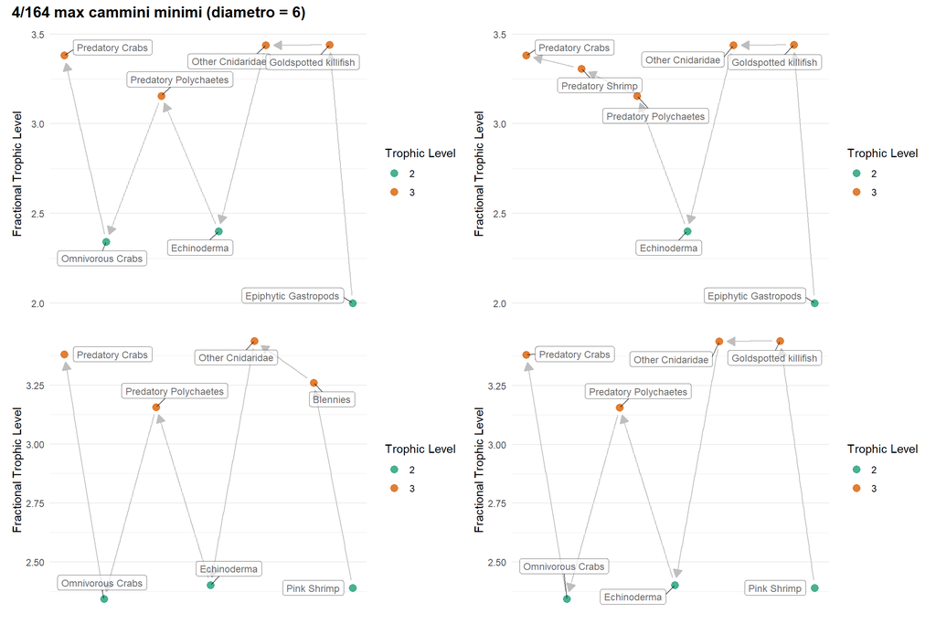

```r
# Calcola la lunghezza del diametro
diam = diameter(g, directed = TRUE)
# Calcola la matrice delle distanze
dist_matrix = distances(g, mode = "out")
# Trova tutte le coppie di nodi con distanza = diametro
pairs = which(dist_matrix == diam, arr.ind = TRUE)

# Estrai tutti i cammini minimi delle coppie
diameter_edges = apply(pairs, 1, function(pair) {
  all_shortest_paths(g, from = pair[1], to = pair[2], mode = "out")$epath
})
# Rendiamo i cammini una lista di liste
diameter_edges = unlist(diameter_edges, recursive = FALSE)


nrows = 2
ncols = 2
nplots = nrows * ncols
ndiams = length(diameter_edges)
diameters = diameter_edges[1:min(nplots, ndiams)]

plot_list = lapply(diameters, function(edges){

  # Crea subgrafo per questo cammino
  fw_g_path = subgraph_from_edges(g, eids = edges)

  coords_path = layout_igraph_constrained_stress(
    fw_g_path,
    coord = V(fw_g_path)$trophic_lvl,
    fixdim = "y"
  )

  p = ggraph(fw_g_path, layout = "manual", x = coords_path$x, y = coords_path$y) +
    geom_edge_fan(
      edge_colour = "grey",
      arrow = arrow(length = unit(3, 'mm'), type = "closed"),
      end_cap = circle(2.5, 'mm'),
      start_cap = circle(2.5, 'mm')
    ) +
    geom_node_point(aes(color = factor(trophic_lvl_int)), size = 3, alpha = 0.8) +
    geom_node_label(
      aes(label = name),
      size = 3.2,
      repel = TRUE,
      alpha = 0.6,
      box.padding = 0.5
    ) +
    scale_color_manual(values = get_tl_colors(), name = "Trophic Level") +
    scale_y_continuous(name = "Fractional Trophic Level") +
    theme_minimal() +
    theme(
      axis.title.x = element_blank(),
      axis.text.x = element_blank(),
      axis.ticks.x = element_blank(),
      panel.grid.major.x = element_blank(),
      panel.grid.minor.x = element_blank()
    )

  return(p)
})


wrap_plots(plot_list, ncol = ncols, nrow = nrows) +
  plot_annotation(
    title = paste0(length(plot_list), "/", ndiams, " max cammini minimi (diametro = ", diam, ")"),
    theme = theme(plot.title = element_text(size = 14, face = "bold"))
  )
```

## Conclusioni

In questa analisi abbiamo analizzato diversi aspetti locali, comunitari e globali della rete. E’ emerso come la maggior parte della bioamassa sia contenuta nei detriti e nel primo livello trofico. Successvamente abbiamo analizzato l’efficenza energetica della rete osservando come questa cala da livello trofico a livello trofico. Dal punto di vista comunitario abbiamo estratto diversi compartimenti con all’interno eterogeneità di livelli trofici. Globalmente, abbiamo osservato come i detriti sono fondamentali affinchè la rete risulti in una grande componente fortemente connesse e che inoltre la rete presenta un effetto small-world.